# Analysis of 450k data using minfi

# 6 Genetic variants and cell type composition

## 6.1 SNPs

Because the presence of SNPs inside the probe body or at the nucleotide extension can have important consequences on the downstream analysis, *minfi* offers the possibility to remove such probes. The function `getSnpInfo`, applied to a `GenomicRatioSet`, returns a data frame with 6 columns containing the SNP information of the probes:

```r
snps <- getSnpInfo(GRset)
head(snps,10)
```

```
## DataFrame with 10 rows and 6 columns
##               Probe_rs Probe_maf      CpG_rs   CpG_maf      SBE_rs
##            <character> <numeric> <character> <numeric> <character>
## cg13869341          NA        NA          NA        NA          NA
## cg14008030          NA        NA          NA        NA          NA
## cg12045430          NA        NA          NA        NA          NA
## cg20826792          NA        NA          NA        NA          NA
## cg00381604          NA        NA          NA        NA          NA
## cg20253340          NA        NA          NA        NA          NA
## cg21870274          NA        NA          NA        NA          NA
## cg03130891  rs77418980  0.305556          NA        NA          NA
## cg24335620 rs147502335  0.012800          NA        NA          NA
## cg16162899          NA        NA          NA        NA          NA
##              SBE_maf
##            <numeric>
## cg13869341        NA
## cg14008030        NA
## cg12045430        NA
## cg20826792        NA
## cg00381604        NA
## cg20253340        NA
## cg21870274        NA
## cg03130891        NA
## cg24335620        NA
## cg16162899        NA
```

`Probe`, `CpG` and `SBE` correspond to the SNPs present inside the probe body, at the CpG interrogation and at the single nucleotide extension, respectively. The columns with `rs` give the names of the SNPs while the columns with `maf` gives the minor allele frequency of the SNPs based on the dbSNP database. The function `addSnpInfo` will add to the `GenomicRanges` of the `GenomicRatioSet` the 6 columns:

```r
GRset <- addSnpInfo(GRset)
```

We strongly recommend to drop the probes that contain either a SNP at the CpG interrogation or at the single nucleotide extension.The function `dropLociWithSnps` allows to drop the corresponding probes. Here is an example where we drop the probes containing a SNP at the CpG interrogation and/or at the single nucleotide extension, for any minor allele frequency:

```r
GRset <- dropLociWithSnps(GRset, snps=c("SBE","CpG"), maf=0)
```

## 6.2 Cell type composition

As shown in (Andrew E Jaffe and Rafael A Irizarry 2014), biological findings in blood samples can often be confounded with cell type composition. In order to estimate the confounding levels between phenotype and cell type composition, the function `estimateCellCounts`, depending on the package *FlowSorted.Blood.450k*, estimates the cell type composition of blood samples by using a modified version of the algorithm described in (E Andres Houseman et al. 2012). The function takes as input a `RGChannelSet` and returns a cell counts vector for each samples:

```r
library(FlowSorted.Blood.450k)
cellCounts <- estimateCellCounts(RGSet)
```

# 7 Identifying DMRs and DMPs

## 7.1 dmpFinder: to find differentially methylated positions (DMPs)

While we do not particularly encourage a single position differential methylation analysis, the function `dmpFinder` finds differentially methylated positions (DMPs) with respect to a phenotype covariate. The phenotype may be categorical (e.g. cancer vs. normal) or continuous (e.g. blood pressure). Below is an example of a DMP analysis for age using the `GRset.funnorm` object created above:

```r
beta <- getBeta(GRset.funnorm)
age  <- pData(GRset.funnorm)$age
dmp <- dmpFinder(beta, pheno = age, type = "continuous")
head(dmp)
```

```
##                 intercept          beta         t            pval
## cg19995126  1.99049395096 -0.0235606444 -69.25397 0.0000002604769
## cg10467968  0.33200063973  0.0069860611  39.02973 0.0000025743700
## cg11425201  0.84524865315  0.0009700050  37.07724 0.0000031595005
## cg24814628  1.02073293826 -0.0025065546 -28.23109 0.0000093673452
## cg01854459  0.06101549223 -0.0003851095 -25.47377 0.0000141035988
## cg26634885 -0.00007791584  0.0002179788  24.33811 0.0000169095338
##                 qval
## cg19995126 0.1264647
## cg10467968 0.5113251
## cg11425201 0.5113251
## cg24814628 0.9583333
## cg01854459 0.9583333
## cg26634885 0.9583333
```

The function is essentially a wrapper around `lmFit` from *limma*.

## 7.2 Plotting DMPs

It’s always a good idea to visualise the results of a differential analysis, which we can do using the `plotCpg` function:

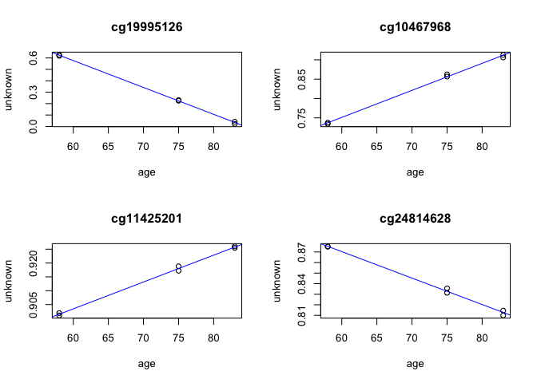

```r
cpgs <- rownames(dmp)[1:4]
par(mfrow = c(2, 2))
plotCpg(getBeta(GRset.funnorm),
        cpg = cpgs,
        pheno = age,
        type = "continuous",
        xlab = "age")
```

## 7.3 bumphunter: to find differentially methylated regions (DMRs)

The `bumphunter` function in minfi is a version of the bump hunting algorithm (Andrew E Jaffe et al. 2012) adapted to the 450k array, relying on the `bumphunter` function implemented in the eponymous *bumphunter* package.

Instead of looking for association between a single genomic location and a phenotype of interest, `bumphunter` looks for genomic regions that are differentially methylated between two conditions. In the context of the 450k array, the algorithm first defines clusters of probes. Clusters are simply groups of probes such that two consecutive probe locations in the cluster are not separated by more than some distance `maxGap`.

Briefly, the algorithm first computes a t-statistic at each genomic location, with optional smoothing. Then, it defines a candidate region to be a cluster of probes for which all the t-statistics exceed a predefined threshold. To test for significance of the candidate regions, the algorithm uses permutations (defined by the parameter `B`). The permutation scheme is expensive, and can take a few days when the number of candidate bumps is large. To avoid wasting time, we propose the following guideline:

1. Define your phenotype of interest. We will demonstrate the bump hunting algorithm by comparing the cancer samples to the normal samples in our example dataset:

```r
pheno <- pData(GRset.funnorm)$status
designMatrix <- model.matrix(~ pheno)
designMatrix
```

```
##   (Intercept) phenonormal
## 1           1           1
## 2           1           1
## 3           1           0
## 4           1           0
## 5           1           1
## 6           1           0
## attr(,"assign")
## [1] 0 1
## attr(,"contrasts")
## attr(,"contrasts")$pheno
## [1] "contr.treatment"
```

2. Run the algorithm with `B=0` permutation on the Beta-values, with a medium difference cutoff, say `0.2` (which corresponds to `20\%` difference on the Beta-values):

```r
bh_dmrs <- bumphunter(GRset.funnorm,
                      design = designMatrix,
                      cutoff = 0.2,
                      B = 0,
                      type = "Beta")
```

```
## [bumphunterEngine] Using a single core (backend: doSEQ, version: 1.4.3).
```

```
## [bumphunterEngine] Computing coefficients.
```

```
## [bumphunterEngine] Finding regions.
```

```
## [bumphunterEngine] Found 53143 bumps.
```

3. If the number of candidate bumps is large, say $>30000$, increase the cutoff to reduce the number of candidate bumps. The rationale behind this is that the most of the additional candidate regions found by lowering the cutoff will be found to be non-significant after the permutation scheme, and therefore time can be saved by being more stringent on the cutoff (high cutoff).
4. Once you have decided on the cutoff, run the algorithm with a large number of permutations, say `B=1000`:

```r
# NOTE: Don't run, this takes a **long** time
bh_dmrs <- bumphunter(GRset.funnorm,
                      design = designMatrix,
                      cutoff = 0.2,
                      B = 1000,
                      type = "Beta")
```

Since the permutation scheme can be expensive, parallel computation is implemented in the `bumphunter` function. The *[foreach](http://cran.fhcrc.org/web/packages/foreach/index.html)* package allows different parallel `back-ends` that will distribute the computation across multiple cores in a single machine, or across machines in a cluster. For instance, if one wished to use 3 cores, the two following commands have to be run before running bumphunter:

```r
library(doParallel)
registerDoParallel(cores = 3)
```

The results of `bumphunter` are stored in a data frame with the rows being the different differentially methylated regions (DMRs):

```r
names(bh_dmrs)
```

```
## [1] "table"           "coef"            "fitted"          "pvaluesMarginal"
```

```r
head(bh_dmrs$table, n = 3)
```

```
##         chr     start       end      value     area cluster indexStart
## 51503  chr6 133561716 133562776 -0.4563633 15.51635  169283     181000
## 45815 chr13  78492678  78493590 -0.4751277 12.35332   55852     333330
## 49025 chr20  61050560  61051915 -0.4834756 12.08689  122288     459601
##       indexEnd  L clusterL
## 51503   181033 34       43
## 45815   333355 26       50
## 49025   459625 25       26
```

As an example, we have run the bump hunting algorithm to find DMRs between colon and kidney (20 samples each from TCGA), with $B=1000$ permutations, and a cutoff of 0.2 on the Beta values:

```r
# NOTE: The `dmrs` object is included with the tutorial.450k package
library(tutorial.450k)
data("dmrs_B1000_c02")
head(dmrs$table)
```

[output not shown]

The `start` and `end` columns indicate the limiting genomic locations of the DMR; the `value` column indicates the average difference in methylation in the bump, and the `area` column indicates the area of the bump with respect to the 0 line. The `fwer` column returns the family-wise error rate (FWER) of the regions estimated by the permutation scheme. One can filter the results by picking a cutoff on the FWER.

## 7.4 Plotting DMRs

As with DMPs, it’s always a good idea to plot DMRs. *minfi* does not currently include any functionality for doing this directly but will soon[^2]. In the mean time, we can (with a little bit of a work) make a publication-quality figure using the *Gviz*.

**NOTE:** This figure takes a while to generate because *Gviz* needs to first download some data.

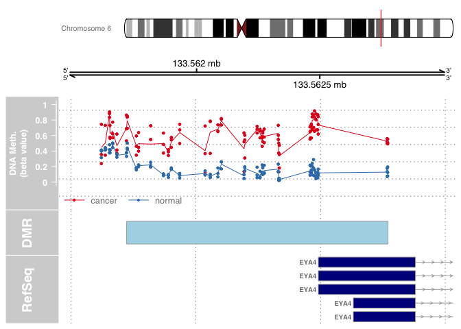

```r
library(Gviz)
genome <- "hg19"
# NOTE: Using the non-permuted
dmr <- bh_dmrs$table[1, ]
chrom <- dmr$chr
start <- dmr$start
end <- dmr$end
minbase <- start - 0.25 * (end - start)
maxbase <- end + 0.25 * (end - start)
pal <- c("#E41A1C", "#377EB8")

# Start building the tracks
iTrack <- IdeogramTrack(genome = genome,
                        chromosome = dmr$chr,
                        name = "")
gTrack <- GenomeAxisTrack(col = "black",
                          cex = 1,
                          name = "",
                          fontcolor = "black")
# NOTE: This track takes a little while to create
rTrack <- UcscTrack(genome = genome,
                    chromosome = chrom,
                    track = "refGene",
                    from = minbase,
                    to = maxbase,
                    trackType = "GeneRegionTrack",
                    rstarts = "exonStarts",
                    rends = "exonEnds",
                    gene = "name",
                    symbol = "name2",
                    transcript = "name",
                    strand = "strand",
                    fill = "darkblue",
                    stacking = "squish",
                    name = "RefSeq",
                    showId = TRUE,
                    geneSymbol = TRUE)
# methylation data track
gr <- granges(GRset.funnorm)
gr$beta <- getBeta(GRset.funnorm)
methTrack <- DataTrack(range = gr,
                       groups = targets$status,
                       genome = genome,
                       chromosome = chrom,
                       ylim = c(-0.05, 1.05),
                       col = pal,
                       type = c("a","p"),
                       name = "DNA Meth.\n(beta value)",
                       background.panel = "white",
                       legend = TRUE,
                       cex.title = 0.8,
                       cex.axis = 0.8,
                       cex.legend = 0.8)
# DMR position data track
dmrTrack <- AnnotationTrack(start = start,
                            end = end,
                            genome = genome,
                            name = "DMR",
                            chromosom = chrom)
# Finally, plot the tracks
tracks <- list(iTrack, gTrack, methTrack, dmrTrack, rTrack)
sizes <- c(2, 2, 5, 2, 3) # set up the relative sizes of the tracks
plotTracks(tracks,
           from = minbase,
           to = maxbase,
           showTitle = TRUE,
           add53 = TRUE,
           add35 = TRUE,
           grid = TRUE,
           lty.grid = 3,
           sizes = sizes,
           length(tracks))
```

## 7.5 Block finder

The approximately 170,000 open sea probes on the 450K array can be used to detect long-range changes in methylation status. These large scale changes that can range up to several Mb have typically been identified only through whole-genome bisulfite sequencing. The function `blockFinder` groups the average methylation values in open-sea probe cluster (via `cpgCollapse`) into large regions, and then run the `bumphunter` algorithm with a large (250KB+) smoothing window (see the bump hunting section for DMRs above).

## 7.6 Batch effects correction with SVA

Surrogate variable analysis (SVA) (Jeffrey T Leek and John D Storey 2007,Jeffrey T Leek and John D Storey (2008)) is a useful tool to identified surrogate variables for unwanted variation while protecting for a phenotype of interest. In our experience, running SVA after normalizing the 450K data with `preprocessFunnorm` or `preprocessQuantile` increases the statistical power of the downstream analysis. For instance, to run SVA on the M-values, protecting for case-control status, the following code can be used to estimate the surrogate variables (this can take a few hours to run on a full dataset):

```r
library(sva)
mval <- getM(GRset)[1:5000,]
pheno <- pData(GRset)
mod <- model.matrix(~as.factor(status), data=pheno)
mod0 <- model.matrix(~1, data=pheno)
sva.results <- sva(mval, mod, mod0)
```

```
## Number of significant surrogate variables is:  2
## Iteration (out of 5 ):1  2  3  4  5
```

Once the surrogate variables are computed, one can include them in the downstream analysis to adjust for unknown unwanted variation. See the [sva vignette](http://bioconductor.org/packages/release/bioc/vignettes/sva/inst/doc/sva.pdf) for a more comprehensive use of `sva`.

## 7.7 Importing data from The Cancer Genome Atlas (TCGA)

The package tcgaR directly imports 450k methylation data into R from the TCGA portal by building an `RGChannelSet`. Normal and tumor samples are available for more than 20 cancer types. The package also contains convenient functions to import the corresponding metadata and clinical data.

# 8 Other tasks

## 8.1 A/B compartments prediction.

```r
ab <- compartments(GRset.quantile, chr="chr14", resolution=100000)
```

## 8.2 Potentially useful functions

### 8.2.1 getSnpBeta

The array contains by design 65 probes that are not meant to interrogate methylation status, but instead are designed to interrogate SNPs. By default, minfi drops these probes. The function `getSnpBeta` allows the user to extract the Beta values for those probes from an `RGChannelSet`. The return object is a matrix with the columns being the samples and the rows being the different SNP probes:

```r
snps <- getSnpBeta(RGSet)
head(snps)
```

```
##            5723646052_R02C02 5723646052_R04C01 5723646052_R05C02
## rs1019916         0.44141800        0.50740172         0.4854442
## rs10457834        0.50760422        0.55113785         0.6654530
## rs1416770         0.06412214        0.04665314         0.1041461
## rs1941955         0.94617711        0.49905060         0.9499797
## rs2125573         0.54285459        0.56833273         0.6112521
## rs2235751         0.47123623        0.47824994         0.3911962
##            5723646053_R04C02 5723646053_R05C02 5723646053_R06C02
## rs1019916         0.57308474        0.52069297         0.8387841
## rs10457834        0.42238892        0.55499709         0.5689888
## rs1416770         0.91858483        0.93748229         0.1125396
## rs1941955         0.90839010        0.93859649         0.7683307
## rs2125573         0.11020630        0.11503778         0.8059526
## rs2235751         0.06187767        0.06915974         0.5231096
```

These SNP probes are intended to be used for sample tracking and sample mixups. Each SNP probe ought to have values clustered around 3 distinct values corresponding to homo-, and hetero-zygotes.

### 8.2.2 Out-of-band probes

The function `getOOB` applied to an `RGChannelSet` retrieves the so-called `out-of-band` (OOB) probes. These are the measurements of Type I probes in the “wrong” color channel. They are used in the `preprocessNoob` and `preprocessFunnorm` functions to estimate background noise. The function returns a list with two matrices, named `Red` and `Grn`.

```r
oob <- getOOB(RGSet)
```

# 9 shinyMethyl

*shinyMethyl* provides interactive visualisation of Illumina 450k methylation arrays that can be useful for performing quality control, particularly of larger datasets. For further details, please consult the [shinyMethyl vignette](http://bioconductor.org/packages/release/bioc/shinyMethyl/sva/inst/doc/shinyMethyl.pdf)

We briefly demonstrate the functionality of *shinyMethyl* using an example dataset that contains the extracted data of 369 Head and Neck cancer samples downloaded from The Cancer Genome Atlas (TCGA) data portal (The Cancer Genome Atlas 2014): 310 tumor samples, 50 matched normals and 9 replicates of a control cell line. The first `shinyMethylSet` object was created from the raw data (no normalization) and is stored under the name `summary.tcga.raw`; the second `shinyMethylSet` object was created from a `GenomicRatioSet` containing the normalized data and the file is stored under the name the name `summary.tcga.norm`

```r
library(shinyMethyl)
library(shinyMethylData)
runShinyMethyl(summary.tcga.raw, summary.tcga.norm)
```

# 10 Session information

As last part of this document, we call the function `sessionInfo`, which reports the version numbers of R and all the packages used in this session. It is good practice to always keep such a record as it will help to trace down what has happened in case that an R script ceases to work because the functions have been changed in a newer version of a package. The session information should also **always** be included in any emails to the [Bioconductor support site](https://support.bioconductor.org) along with all code used in the analysis.

[session information not shown]

# References

Andrew E Jaffe, and Rafael A Irizarry. 2014. “Accounting for cellular heterogeneity is critical in epigenome-wide association studies.” *Genome Biology* 15 (2): R31. doi:10.1186/gb-2014-15-2-r31.

Andrew E Jaffe, Peter Murakami, Hwajin Lee, Jeffrey T Leek, M Daniele Fallin, Andrew P Feinberg, and Rafael A Irizarry. 2012. “Bump hunting to identify differentially methylated regions in epigenetic epidemiology studies.” *International Journal of Epidemiology* 41 (1): 200–209. doi:10.1093/ije/dyr238.

E Andres Houseman, William P Accomando, Devin C Koestler, Brock C Christensen, Carmen J Marsit, Heather H Nelson, John K Wiencke, and Karl T Kelsey. 2012. “DNA methylation arrays as surrogate measures of cell mixture distribution.” *BMC Bioinformatics* 13 (1): 86. doi:10.1186/1471-2105-13-86.

Jean-Philippe Fortin, and Kasper D Hansen. 2015. “Reconstructing a/B Compartments as Revealed by Hi-c Using Long-Range Correlations in Epigenetic Data.” *Genome Biology* 16 (1). Springer: 1–23.

Jean-Philippe Fortin, Aurélie Labbe, Mathieu Lemire, Brent W Zanke, Thomas J Hudson, Elana J Fertig, Celia MT Greenwood, and Kasper D Hansen. 2014. “Functional normalization of 450k methylation array data improves replication in large cancer studies.” *Genome Biology* 15 (11): 503. doi:10.1186/s13059-014-0503-2.

Jeffrey T Leek, and John D Storey. 2007. “Capturing heterogeneity in gene expression studies by surrogate variable analysis.” *PLoS Genetics* 3 (9): 1724–35. doi:10.1371/journal.pgen.0030161.

———. 2008. “A general framework for multiple testing dependence.” *Proceedings of the National Academy of Sciences* 105 (48): 18718–23. doi:10.1073/pnas.0808709105.

Jovana Maksimovic, Lavinia Gordon, and Alicia Oshlack. 2012. “SWAN: Subset quantile Within-Array Normalization for Illumina Infinium HumanMethylation450 BeadChips.” *Genome Biology* 13 (6): R44. doi:10.1186/gb-2012-13-6-r44.

Martin J Aryee, Andrew E Jaffe, Hector Corrada Bravo, Christine Ladd-Acosta, Andrew P Feinberg, Kasper D Hansen, and Rafael A Irizarry. 2014. “Minfi: a flexible and comprehensive Bioconductor package for the analysis of Infinium DNA methylation microarrays.” *Bioinformatics* 30 (10): 1363–9. doi:10.1093/bioinformatics/btu049.

Nizar Touleimat, and Jörg Tost. 2012. “Complete pipeline for Infinium Human Methylation 450K BeadChip data processing using subset quantile normalization for accurate DNA methylation estimation.” *Epigenomics* 4 (3): 325–41. doi:10.2217/epi.12.21.

The Cancer Genome Atlas. 2014. *Data Portal*. https://tcga-data.nci.nih.gov/tcga/.

Timothy J Triche, Daniel J Weisenberger, David Van Den Berg, Peter W Laird, and Kimberly D Siegmund. 2013. “Low-level processing of Illumina Infinium DNA Methylation BeadArrays.” *Nucleic Acids Research* 41 (7): e90. doi:10.1093/nar/gkt090.

[^1]: The `read.metharray`, `read.metharray.exp`, and `read.metharray.sheet` functions supersede the now-deprecated `read.450k`, `read.450k.exp`, and `read.450k.sheet` functions, respectively. These functions were renamed because they now also support the EPIC array.
[^2]: Famous last words …